# Reproducible Research: Peer Assessment 1

## Introduction

It is now possible to collect a large amount of data about personal movement using activity monitoring devices such as a Fitbit, Nike Fuelband, or Jawbone Up. These type of devices are part of the “quantified self” movement - a group of enthusiasts who take measurements about themselves regularly to improve their health, to find patterns in their behavior, or because they are tech geeks. But these data remain under-utilized both because the raw data are hard to obtain and there is a lack of statistical methods and software for processing and interpreting the data.

This assignment makes use of data from a personal activity monitoring device. This device collects data at 5 minute intervals through out the day. The data consists of two months of data from an anonymous individual collected during the months of October and November, 2012 and include the number of steps taken in 5 minute intervals each day.

The data for this assignment can be downloaded from the course web site:

Dataset: [Activity monitoring data](https://d396qusza40orc.cloudfront.net/repdata%2Fdata%2Factivity.zip) [52K]

The variables included in this dataset are:

- **steps**: Number of steps taking in a 5-minute interval (missing values are coded as NA)
- **date**: The date on which the measurement was taken in YYYY-MM-DD format
- **interval**: Identifier for the 5-minute interval in which measurement was taken

The dataset is stored in a comma-separated-value (CSV) file and there are a total of 17,568 observations in this dataset.

## Loading and preprocessing the data

We use dplyr library for row data check after loading

```r
library(dplyr)
```

After data loading we detect indexing of interval values using HHMM format. Let’s check if it’s correct and has no hidden gaps. Fix it by adding new column with better index.

```r
data <- read.csv("activity.csv", stringsAsFactors = FALSE)
data$date <- as.POSIXct(data$date,format="%Y-%m-%d")
summary(data)
```

```
##      steps             date               interval
##  Min.   :  0.00   Min.   :2012-10-01   Min.   :   0.0
##  1st Qu.:  0.00   1st Qu.:2012-10-16   1st Qu.: 588.8
##  Median :  0.00   Median :2012-10-31   Median :1177.5
##  Mean   : 37.38   Mean   :2012-10-31   Mean   :1177.5
##  3rd Qu.: 12.00   3rd Qu.:2012-11-15   3rd Qu.:1766.2
##  Max.   :806.00   Max.   :2012-11-30   Max.   :2355.0
##  NA's   :2304
```

```r
dim(data)
```

```
## [1] 17568     3
```

```r
by_date<-group_by(data, date)
intervals<-aggregate(interval ~ date, data, function(x) length(unique(x)))
summary(intervals)
```

```
##       date               interval
##  Min.   :2012-10-01   Min.   :288
##  1st Qu.:2012-10-16   1st Qu.:288
##  Median :2012-10-31   Median :288
##  Mean   :2012-10-31   Mean   :288
##  3rd Qu.:2012-11-15   3rd Qu.:288
##  Max.   :2012-11-30   Max.   :288
```

```r
dim(intervals)
```

```
## [1] 61  2
```

Intervals have exactly 288 unique values per day. But numeric range of these values may be misleading and needs fixing.

```r
# Each day includes 288 = 24*12 5 min long intervals. The problem is that numbers in the interval column have poor numeration: 2355 different values instead of 288.
# We add new interval_id column to fix this issue
data <- cbind(data, interval_id=rep(1:288,61))
```

## What is mean total number of steps taken per day?

To get the answer we use our data groupped bu date and summarize it by calculating sum of steps.

```r
dayresults<-summarize(by_date, daily_step_sum=sum(steps, na.rm=TRUE))
with(dayresults, hist(daily_step_sum))
summary(dayresults)
```

```
##       date            daily_step_sum
##  Min.   :2012-10-01   Min.   :    0
##  1st Qu.:2012-10-16   1st Qu.: 6778
##  Median :2012-10-31   Median :10395
##  Mean   :2012-10-31   Mean   : 9354
##  3rd Qu.:2012-11-15   3rd Qu.:12811
##  Max.   :2012-11-30   Max.   :21194
```

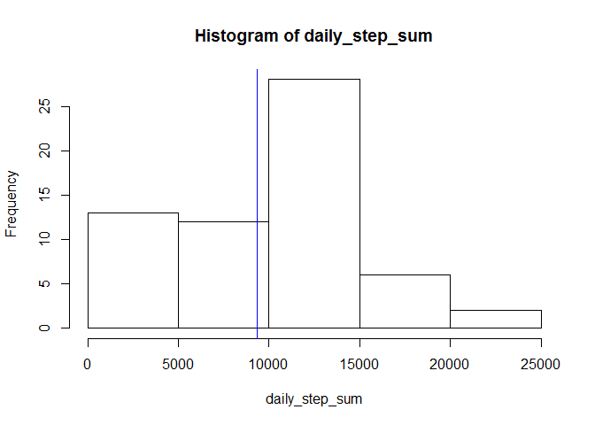

```r
m<-mean(dayresults$daily_step_sum, na.rm = TRUE)
abline(v=m, col="blue")
```

```r
median<-median(dayresults$daily_step_sum, na.rm = TRUE)
#mean
m
```

```
## [1] 9354.23
```

```r
#median
median
```

```
## [1] 10395
```

## What is the average daily activity pattern?

```r
by_interval_id <- group_by(data, interval_id)

intervalmeans<-summarize(by_interval_id, daily_interval_means=mean(steps, na.rm=TRUE))
summary(intervalmeans)
```

```
##   interval_id     daily_interval_means
##  Min.   :  1.00   Min.   :  0.000
##  1st Qu.: 72.75   1st Qu.:  2.486
##  Median :144.50   Median : 34.113
##  Mean   :144.50   Mean   : 37.383
##  3rd Qu.:216.25   3rd Qu.: 52.835
##  Max.   :288.00   Max.   :206.170
```

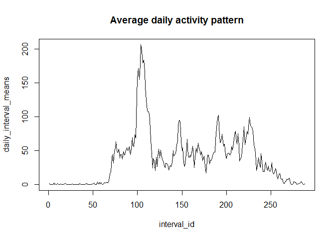

```r
with(intervalmeans, plot(x=interval_id, y=daily_interval_means, type="l"))
title(main = "Average daily activity pattern")
```

```r
interval_with_max_steps <- which.max(intervalmeans$daily_interval_means)
#number of interval_with_max_steps
intervalmeans$interval_id[interval_with_max_steps]
```

```
## [1] 104
```

```r
# maximum number of steps for average 5 min interval
intervalmeans$daily_interval_means[interval_with_max_steps]
```

```
## [1] 206.1698
```

We see that people who generated the data set were quite close to 10,000 steps goal. Good job!

## Imputing missing values

We apply daily activity pattern to impute missing steps values

```r
# investigate on NAs in steps

st<-table(is.na(data$steps))
st
```

```
##
## FALSE  TRUE
## 15264  2304
```

```r
# missing values in %%
as.numeric(st[2]/(st[1]+st[2]))
```

```
## [1] 0.1311475
```

```r
na_intervals <- is.na(data$steps)
summary(na_intervals)
```

```
##    Mode   FALSE    TRUE
## logical   15264    2304
```

```r
# iputing NA step values with average for the intervals

data_imputed <- data

data_imputed$steps[na_intervals] <- rep(intervalmeans$daily_interval_means, 61)[na_intervals]

head(data_imputed)
```

```
##       steps       date interval interval_id
## 1 1.7169811 2012-10-01        0           1
## 2 0.3396226 2012-10-01        5           2
## 3 0.1320755 2012-10-01       10           3
## 4 0.1509434 2012-10-01       15           4
## 5 0.0754717 2012-10-01       20           5
## 6 2.0943396 2012-10-01       25           6
```

```r
#double check that we did not break non-NA values
table(data$steps==data_imputed$steps)
```

```
##
##  TRUE
## 15264
```

```r
by_date_imp<-group_by(data_imputed, date)
dayresults_imp<-summarize(by_date_imp, daily_step_sum=sum(steps, na.rm=TRUE))
with(dayresults_imp, hist(daily_step_sum))

summary(dayresults_imp)
```

```
##       date            daily_step_sum
##  Min.   :2012-10-01   Min.   :   41
##  1st Qu.:2012-10-16   1st Qu.: 9819
##  Median :2012-10-31   Median :10766
##  Mean   :2012-10-31   Mean   :10766
##  3rd Qu.:2012-11-15   3rd Qu.:12811
##  Max.   :2012-11-30   Max.   :21194
```

[figure not shown]

```r
m_imp <- mean(dayresults_imp$daily_step_sum, na.rm = TRUE)
abline(v=m_imp, col="blue")
```

```r
median_imp <- median(dayresults_imp$daily_step_sum, na.rm = TRUE)
#mean
m_imp
```

```
## [1] 10766.19
```

```r
#median
median_imp
```

```
## [1] 10766.19
```

```r
# previous values
#mean
m
```

```
## [1] 9354.23
```

```r
#median
median
```

```
## [1] 10395
```

Imputing missed values really impacted data.

## Are there differences in activity patterns between weekdays and weekends?

```r
data_imputed <- mutate(data_imputed, isweekend = weekdays(date, abbreviate =TRUE) %in% c("Sat", "Sun"))
data_imputed$isweekend <- as.factor(data_imputed$isweekend)
levels(data_imputed$isweekend) <- c("weekday", "weekend")
str(data_imputed)
```

```
## 'data.frame':    17568 obs. of  5 variables:
##  $ steps      : num  1.717 0.3396 0.1321 0.1509 0.0755 ...
##  $ date       : POSIXct, format: "2012-10-01" "2012-10-01" ...
##  $ interval   : int  0 5 10 15 20 25 30 35 40 45 ...
##  $ interval_id: int  1 2 3 4 5 6 7 8 9 10 ...
##  $ isweekend  : Factor w/ 2 levels "weekday","weekend": 1 1 1 1 1 1 1 1 1 1 ...
```

```r
by_date_isweekend <- group_by(data_imputed, isweekend, interval_id)

intervalmeans <- summarize(by_date_isweekend, daily_interval_means=mean(steps, na.rm=TRUE))
summary(intervalmeans)
```

```
##    isweekend    interval_id     daily_interval_means
##  weekday:288   Min.   :  1.00   Min.   :  0.000
##  weekend:288   1st Qu.: 72.75   1st Qu.:  2.047
##                Median :144.50   Median : 28.133
##                Mean   :144.50   Mean   : 38.988
##                3rd Qu.:216.25   3rd Qu.: 61.263
##                Max.   :288.00   Max.   :230.378
```

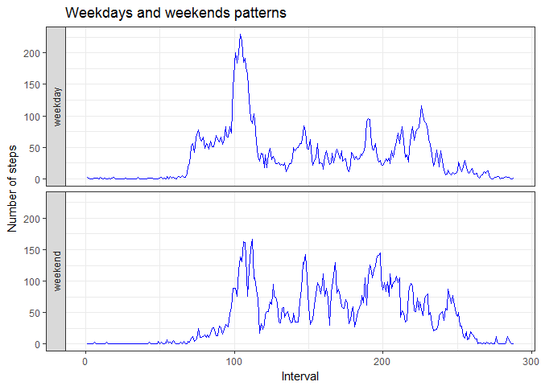

```r
library(ggplot2)

g <- ggplot(intervalmeans, aes(x = interval_id, y = daily_interval_means))
g<-g+geom_line(colour = 'blue')+facet_grid(isweekend ~., switch = "both") +theme_bw()
g+labs(x="Interval", y="Number of steps", title="Weekdays and weekends patterns")
```

Weekdays and weekends have different patterns for activity. For example, we see that people are not so active in weekend mornings. They are more passive in working hours (probably because of looking into monitors instead of making steps).